# Introduction to Python

## [UCSAS 2021](https://statds.org/events/ucsas2021/) Conference

## Surya Teja Eada

## October 09, 2021

## About Me

Third year Ph.D. student from Department of Statistics at UConn

**Research Interests**:

- Stochastic Processes, Diffusion Processes.
- Financial Risk Modeling, Model Risk Assessment.

**Aspirations**:

- Collaborate in various domains to contribute with Statistics.
- Research and Academics

**Hobbies**:

- Sports, Painting, Travel, Learning new things

## Prerequisites

- Prerequsites: A laptop with Anaconda installed. Anaconda can be downloaded for windows users [here](https://repo.anaconda.com/archive/Anaconda3-2020.07-Windows-x86_64.exe) and for Mac users [here](https://repo.anaconda.com/archive/Anaconda3-2020.07-MacOSX-x86_64.pkg).
- The slides and Practice workbook for today's workshop can be found at: [Github UCSAS 2021](https://github.com/suryaeada9/ucsas_intro_python)

### Anaconda

- When you install Anaconda GUI (package manager), it comes with `Python 3.8` (not the latest one), `pip 20`, `conda forge` and most of the important modules such as `Numpy`, `Scipy`, `Matplotlib`, etc.
- Anaconda allows to keep track of useful modules along with right version required for your project via environments
- pip and conda forge allows for these without a GUI using command line.
- [More](https://conda.io/projects/conda/en/latest/user-guide/tasks/manage-environments.html#creating-an-environment-with-commands) documentation on how conda allows to create environments are available here.
- Anaconda also provides Jupyter notebook, a very useful tool in data science similar to Rmarkdown allowing for markdown and code runs.
- Furthermore a library full of documentation regarding important modules is present as you can see below:

[figure not shown]

## Motivation

Let us look from around us what brings motivation to learning a new language.

- Data is growing richer, bigger and broader and that means more application of Data Science
- Python provides us with a utilitarian, easy to read and write language
- Most deep learning models are implemented here first and there is a lot of demand for Python
- It is an open source which implies it improves all the time
- And also adaptation is key to survival with the job market

[figure not shown]

## Python Intro

- Python is one of the most promising programming language released in 1991 by `Guido Van Rossum`.
- It is useful for creation of web applications, for software development, and now a lot in data science and constantly evolving.
- It has an easy `syntax` similar to English, simple to read and write.
- The most recent major version of Python is `Python 3.10` although Python 2 is still used majorly inside mac systems for development.
- We can use Python via `command line`, IDE's like `PyCharm`, or applications such as `Jupyter Notebook`.
- Python works on all the different platforms like `Windows, Mac, Linux`.

## Workshop Aim

- **Python Syntax**: `Variable`, `Indentation`, `Comments`, `Help`
- **Data Types and Methods**: Mutable and Immutable
  - **Text Type**: `str`
  - **Numeric Types**: `int, float, complex`
  - **Sequence Types**: `list, tuple, range`
  - **Mapping Type**: `dict`
  - **Set Types**: `set, frozenset`
  - **Boolean Type**: `bool`
  - **Numpy module**: `array`
  - **Pandas module**: `DataFrame`
- **Conditions, Loops, Functions**
- **Basic Modules** and respective Functions
  - **`numpy`**: Arrays, Universal Functions (Vectorized), Random numbers (Simulations)
  - **`pandas`**: DataFrames, Data Manipulation
  - Miscellaneous
- **Quiz**

## Let's get Started

- We will be working on Jupyter Notebook.
- Open `Practice.ipynb` located in the [Github UCSAS 2021](https://github.com/suryaeada9/ucsas_intro_python).
- Download the file `Practice.ipynb`
- Open a Jupyter notebook from Anaconda GUI or from command line using command `jupyter notebook`

## Jupyter Notebook

### Some Useful comments for Jupyter

- In order to work with a jupyter notebook that allows for `markdown` and `code chunks`, it is most importanat to note the difference between `command` mode and `edit` mode.
  - `Command` mode is activated when a `blue border` is around the highlighted chunk and often can be obtained by pressing `ESC`
  - This implies that you can add a new chunk using `A` or `B`, change the current chunk into a markdown chunk using `M`, or a code chunk using `Y`, activate help to find all shortcuts using `H`
  - During the `Command` mode anything you type is considered a command for the notebook and will not be typed into the chunk.
  - `Edit` mode is activated when a `green border` is highlighting the chunk you are at and can be attained by pressing `Enter`.
  - This implies you are editing the current chunk by writing code or text depending on the type of chunk it is.
  - A code chunk can be determined by a `In []` to the left of the chunk and a markdown chunk does not have the same. Moreover, a markdown chunk can be run using `CMD + ENTER` in which case it looks like a PDF.

### Python Installation Check and our first Python run

```python
## Check Python Installation & Version (`!`)
!python --version

## print Hello World
print("Hello World!")
```

```
Python 3.8.8
Hello World!
```

## Python "f-string" and "input" function

- Python "f-string" allows concatenation of strings with variables

```python
## taking user input
name = input("Enter your name: ")
age  = input("Enter your age: ")
print(f"My name is {name} and I am {age} years old")
```

```
Enter your name: Surya
Enter your age: 29
My name is Surya and I am 29 years old
```

## Save this a source file to run multiple times

%save is a magic function that allows us to save a source file once we like a function run, application run etc by running it in Jupyter and using the chunk number dynamically as an input.

```python
## magic command allows you to save second run chunk in `.py`
## and -a allows to append to that rather than overwrite.

## I will run this once and comment it as it is a dynamic function
## and I don't want to create mutliple files.

# %save firstscript.py -n 2 -a
```

- `!` allows for magic use of `bash` within jupyter notebook.
- `%save` allows for magic save of a code chunk into a `.py` file that you can run using python in bash.

## Python Syntax

- Python uses `new line` to inform `end` of command or function.
- This is unlike other programs that use brackets or semi-colons.

### Comments

- Comments are applied using `#` or apply shortcut `CMD + /`

```python
# Demo: Print, End of command, Commenting
print("Hello UCSAS")
print("Workshop is going good??")
```

```
Hello UCSAS
Workshop is going good??
```

## Python Syntax

### Variable Assignment

- Variable is a pointer associated to an object (int, list) in Python and thus stores address of where the object is saved.
- We use "=" for assignment of a variable to such a name.
- We can assign integers, floats, strings, boolean, lists, functions or any class object to a variable.
- Python also allows multiple assignment in a single line from multiple objects or single list.
- "is" verifies if it is the same object in the same address while "==" verifies the equality pointwise.

```python
# Integer Assignment to a variable
x = 2

# String
z = "UCSAS"

## Boolean
w = True


print(x)
print(z)
print(w)
```

```
2
UCSAS
True
```

```python
## list
a = [1, 2, 3, 4]

## function
def function_that_adds_10(x):
    return(x + 10)

f = function_that_adds_10

print(a)
print(f(2))
```

```
[1, 2, 3, 4]
12
```

```python
## Mutliple Assignment at once
a1,  a2, a3 = 2, "UCSAS", True

print(a1, ',', a2, ',', a3)
```

```
2 , UCSAS , True
```

### Indentation

- Indentation refers to the spaces at the beginning of a code line used to inform scope of conditional, loop, or a function.
  - You have to use some white space and it depends on programmer but should be `at least one space`
  - Use `same number` of space in same block of code
  - It informs that the next line does not mean end of the earlier code

```python
# Indentation using one space to continue `if`
# Also see the use of `:`
x = 0

if x>2:
 print("x greater than 2")
else:
 print("x less than 2")
```

```
x less than 2
```

### Help in Python

```python
## Using dir to find the methods for list
MyClass = list
method_list = [method for method in dir(MyClass) if method.startswith('__') is False]
print(method_list)

## Help on function `sum`
help(sum)

## application of function `sum`.
x = [1, 2, 3]
sum(x, 2)
```

```
['append', 'clear', 'copy', 'count', 'extend', 'index', 'insert', 'pop', 'remove', 'reverse', 'sort']
Help on built-in function sum in module builtins:

sum(iterable, /, start=0)
    Return the sum of a 'start' value (default: 0) plus an iterable of numbers

    When the iterable is empty, return the start value.
    This function is intended specifically for use with numeric values and may
    reject non-numeric types.
```

```
8
```

## Quiz on Help with variables:

Use the above manner of using `dir` to find the list of methods applicable to class `list` and apply those that are most appropriate for the following task:

**Task:** Use `x = [3, 10, 7]` to create a variable x for the list, and using the methods for a `list` and:

- concatenate 4 to the list
- sort in descending order
- remove the item at index 2 from original variable and return removed value to a new variable
- clear the entire list
- Also find using help, the difference between `pop` and `remove`.

  Use print statements at the end of every task to view x at the end of every method application.

**Note:** If you are unsure of a particular method, use `help(type.method)` or `help(object.method)`

```python
## Initiate a list
x = [3, 10, 7]
print([method for method in dir(x) if method.startswith('__') is False])
```

```
['append', 'clear', 'copy', 'count', 'extend', 'index', 'insert', 'pop', 'remove', 'reverse', 'sort']
```

```python
## Append 4
x.append(4)
print(x)
```

```
[3, 10, 7, 4]
```

```python
# Sort in ascending
x.sort()
print(x)
```

```
[3, 4, 7, 10]
```

```python
# Reverse order
x.reverse()
print(x)
```

```
[10, 7, 4, 3]
```

```python
# Pop and remove application
y = x.pop(2)  ## uses index, defaults last
print(x)
print(y)
x.remove(3)  ## uses value, removes its first occurence, no default
print(x)
```

```
[10, 7, 3]
4
[10, 7]
```

```python
## Clear
x.clear()
print(x)

print(help(x.pop))
print(help(x.remove))
```

```
[]
Help on built-in function pop:

pop(index=-1, /) method of builtins.list instance
    Remove and return item at index (default last).

    Raises IndexError if list is empty or index is out of range.

None
Help on built-in function remove:

remove(value, /) method of builtins.list instance
    Remove first occurrence of value.

    Raises ValueError if the value is not present.

None
```

## Data Types, Methods, Casting.

Every object containing data has a data type that can be found using `type()`. You can access `type()` on the variable pointing to the object.

- **Data Types**:
  - **Text**: `str`
  - **Numeric**: `int, float, complex`
  - **Sequence**: `list, tuple, range`
  - **Mapping**: `dict`
  - **Set**: `set, frozenset`
  - **Boolean**: `bool`
- The above is not an exhaustive set of all possibilities

### Guess/Try:

Do you know what happens if you try `type(type(str))`

### Illustration: Data types

The following is an illustration of obtaining objects of different data types and some of the methods for each of them.

#### String

- String is an array of bytes representing unicode characters and thus elemets can be accessed.
- Multiline strings need three quotes and keep line breaks in tact while printing.
- Operators like `+` concatenates strings, `in` searches for membership
- Commonly used methods:
  - `` replace(`a`, `b`) ``: replaces a with b in string
  - `` split(`,`) ``: splits based on given seperator
  - `count('a')`: counts number of times 'a' occured.
  - `format(a)`: adds variable a at the `{}` left in the string
  - `upper()`, `lower()`, `strip()`, `capitalize()`, `casefold()`, `count('a')`, `endswith()`, `startswith()`, `find()`, `index()`, `isalphabet()`, `isdigit()`

```python
## Primitive type

# String
x = 'abcd'
print(f"`{x}` is of type: {type(x)}")
```

```
`abcd` is of type: <class 'str'>
```

```python
# multiline string
x = '''abcd
let me show what line breaks do'''
print(x)
```

```
abcd
let me show what line breaks do
```

```python
# string access and slicing
x = 'I am at UCSAS'
print(f"`{x[0]}` is the first character in string x")
print(f"`{x[1:10]}` are the next nine characters including spaces")  # from index 1 to index 9
print(f"`{x[:4]}` are the first four characters in x excluding index 4")
print(f"`{x[4:]}` are the characters from location 4 including till end")
print(f"`{x[-1]}` is the last character")
```

```
`I` is the first character in string x
` am at UC` are the next nine characters including spaces
`I am` are the first four characters in x excluding index 4
` at UCSAS` are the characters from location 4 including till end
`S` is the last character
```

```python
# Try using format to indicate
print("at" in x)

# format
x = "I am {} and I teach {}"
x.format('Surya', 'Statistics')
```

```
True
```

```
'I am Surya and I teach Statistics'
```

### Illustration: Data types - `int, float, complex, bool`

- Integer, float, complex determine different kind of numbers in python.
- Boolean is a logical (True or False).
- Numbers can be cast from one type to other on Python (if **"reasonable"** conversion exist) using the syntax: `int(x), bool(x), float(x), complex(x)`

```python
# integer
y = 12
print(f"{y} is of type: {type(y)}")
```

```
12 is of type: <class 'int'>
```

```python
# float
z = 12.0
print(f"{z} if of type: {type(z)}")
```

```
12.0 if of type: <class 'float'>
```

```python
# complex
a = 2 + 3j  # can use J as well, or casting like complex(2, 3)
print(f"{a} is of type: {type(a)}")
```

```
(2+3j) is of type: <class 'complex'>
```

```python
# Boolean
x = True
print(f"{x} is object of type: {type(x)}")
```

```
True is object of type: <class 'bool'>
```

### Data types containing multiple objects:

- In base python, we already have `list`, `tuple`, `range` for sequence like objects that allow repetitions while we have `set`, `dictionary` for objects that contain multiple items but without allowance for replacements.
- `list`:
  - Created using square brackets `x = [1, 2, [1,2], 1, "pen", True]`
  - Can contain any type of elements even a function.
  - Indexed and Ordered as a sequence.
  - Since indexed, it can contain repetitions.
  - index starts with element 0, and continues unlike R.
  - Elements can be accessed using index as `x[0], x[-1], x[0:3], x[:2], x[2:]`s
  - Elements can be modified using `x[1:3] = ["UCSAS", [1,2,3]]`
  - Mutable: Changes easily at the same address.
  - Uses *to unpack elements (similar to tuples) pointwise except the* element can be assigned a list. For example `(a, *b, c) = ('a', [1, 2], 'c', 'd')`. In this case variable `b` points to `[[1, 2], 'c']`
  - Methods: `len(x): length`, `x.insert(2, "Python")`, `x.append("Python")`, `x.remove([1, 2])`, `x.pop(1)`,`del x[1]`, `x.clear()`, `x.sort()`, `y = x.copy()`, `x.extend(y)`

```python
# list
x = [1, 2, "abc", [1, 2]]
print(f"{x} is of type: {type(x)}")

# Indexing
print(f"element in x at index 0 is {x[0]}")

# Slicing
print(f"sliced elements between locations 0 and 3(until location 2) is {x[0:3]}")


## Use of asterik *
[a, *b, c] = ['a', [1, 2], 'c', 'd']
b
```

```
[1, 2, 'abc', [1, 2]] is of type: <class 'list'>
element in x at index 0 is 1
sliced elements between locations 0 and 3(until location 2) is [1, 2, 'abc']
```

```
[[1, 2], 'c']
```

### Data types containing multiple objects:

- `tuple`:
  - Created using ().
  - An equivalent of list but immutable and thus cannot change easily.
  - Accessing is similar to lists.
  - Adding an item may require converting to list, making modification and casting it into a tuple or adding a tuple consisting of on item that need to be added.
  - Removing also needs converting to list and removing an element.
  - Methods: `len(x)`, `x.count('a')`, `x.index()`

```python
# tuple `immutable equivalent of list`
y = (1, 2, [1, 2], 1, "abc")
print(f"{y} is element of type: {type(y)}")

## Slicing or accessing
print(y[1:3])

## Try
print(y + (2,))   ## creating a one element tuple needs a , at the end.
print(y*2)

## Methods
print(y.count(1))

## Check address of tuple after modification.
print(id(y))
print(id(y + (2,)))
```

```
(1, 2, [1, 2], 1, 'abc') is element of type: <class 'tuple'>
(2, [1, 2])
(1, 2, [1, 2], 1, 'abc', 2)
(1, 2, [1, 2], 1, 'abc', 1, 2, [1, 2], 1, 'abc')
2
4381089040
4380560640
```

### Data types containing multiple objects:

- `range`:
  - This is an object similar to list except containing sequential range of integers.
  - Can be created while using `range(start, stop, step)` where step is an integer.

```python
# range(## start, stop, step). Also step can only be integers. This gives i, i+1, ... j-1
z = range(1, 5, 1)
print(f"{z} is element of type: {type(z)}")
```

```
range(1, 5) is element of type: <class 'range'>
```

### Data types containing multiple objects:

- `set`:
  - Created using `{}`
  - Objects within the set can only be simple types or a tuple.
  - Set is not ordered or indexed
  - does not allow replacements
  - accessing is only possible while looping through values in a set
  - is mutable and can change easily but not with the usual ways of accessing
  - `.add()` allows to add an element, `.update()` allows to append set to a set or a list removing duplicates
  - `.remove()` or `.discard()`, `.pop()`
  - `.union()`, `.update()`, `.intersection()`, `.symmetric_difference()`, `.intersection_update()` , `.symmetric_difference_update()`

```python
# set
x = {"ab", "cd", "ed", "ab"}
print(x)

## accessing
print([i for i in x])

# .symmetric_differencee
y = {'ab', 'an', 'bc', 'ed'}
z = x.symmetric_difference(y)
print(z)

x = {(1,2), (2,3)}
print(x)
```

```
{'ab', 'cd', 'ed'}
['ab', 'cd', 'ed']
{'cd', 'bc', 'an'}
{(2, 3), (1, 2)}
```

### Data types containing multiple objects:

- `dict`:
  - dictionary is a mapping of keys to certain values.
  - dict is created explicitly using `{key1:value1, key2:value2}`
  - dict keys are immutable, does not allow replacements and should be like a `frozenset`
  - duplicate values of key will replace the original
  - dictionary values can be mutable or immutable object and can also allow for replacement.
  - dict can also be created using zip function on a set and list as: `dict(zip(set1, list1))`
  - although not sequenced, it can be thought of having an index as the key and thus accessing a value can be done using the key.
  - accessing elements in dict can happen using `dict[key]` to obtain value.
  - accessing all keys can be done using `dict.keys()` and accessing all values can be done using `dict.values()`.

```python
# dict
x = {'a': [1, 2, 3], 'b': (2, 3), 'a': [2, 4]}

# dict can update
x.update({'c':[1, 5]})
print(x)
```

```
{'a': [2, 4], 'b': (2, 3), 'c': [1, 5]}
```

## Mutability and Immutability

- Few data types are mutable and few data types are immutable and Python handles them differently.
- Mutable objects: easy to change, less time expensive, doesn't create a copy
- Immutable objects: expensive to change, creates a copy.
- As a rule of thumb:
  - primitive like types like `int`, `float`, `complex`, `str`, `bool` are immutable
  - container like types like `list`, `set`
  - `dict` contains a mapping of `keys` to `values`.
  - While `dict` values can be mutable or immutable from the above list, `dict` keys are immutable
- Others:
  - `tuple` is immutable equivalent of `list`
  - `frozen set` is immutable equivalent of `set`
- Even though data types can be mutable, we may have some methods or functions that may change location.
- Common way to find an immutable object is trying to change value and observing its id.

## Mutability and Immutability

### **Exception:**

- Immutable objects can contain mutable objects and may allow for mutation in that manner.

#### Check address change

- `id` allows to find the address of the object.
- `is` allows to check if variables are at the same address.

```python
## Primitive objects are immutable
x = 'abcd'
y = 'abcd'
print(id(x))
print(id(y))

x = x.capitalize()
print(id(x))
print(id(y))

## tuples are immutable
x = (1, 2, 3)

try:
    x[1] = 1
except:
    print("Error obtained")
```

```
4381306800
4381306800
4381552048
4381306800
Error obtained
```

```python
## Mutable Data type  - Example: List
x = [1, 2, [1,2]]
y = x
z = x[:]   ## [:] is method that changes location

print(x)
print(y)
print(z)

## is vs ==
print(x is y)
print(x is z)
print(x == z)

## append is a method of class list
a = x.append(4)
x[0] = 2
print(x is y)
print(y)
print(z)
```

```
[1, 2, [1, 2]]
[1, 2, [1, 2]]
[1, 2, [1, 2]]
True
False
True
True
[2, 2, [1, 2], 4]
[1, 2, [1, 2]]
```

## Operators:

- Arithmetic Operators:
  - `add: +, subtract: -, multiply: *, division: /, modulus: %, exponentiation: **, floor division: //`
- Assignment Operators:
  - `equals: =, add and equal: +=, subtract and equal: -=, multiply and equal: *=, divide and equal: /=, remainder and equal: %=, floor division and equal: //=, power and equal: **=`
  - `Boolean and and equal &=, Boolean or and equal |=, Boolean xor and equal ^=`
- Comparison Operators:
  - `value equality: ==, value not equal: !=, value greater than: >, value less than: <, value greater than equal: >=, value less than equal: <=`
- Logical Operators:
  - `and, or, ^, not`
- Identity Operators:
  - `is, is not` (checks for object being same)
- Membership Operators for being part of list or tuple:
  - `in, not in`
- **Note** some operators like add, multiply does a different task on lists than a pointwise addition.

## Data Casting to types

- Some type of data can be cast to a different type as long as it is reasonable.
- Casting can be done using `type name` as a `function`
- For example, an `integer` can be cast into a `float` or a `complex` number. A `float` can become `int` by removing decimals (taking floor). However, a `complex` number cannot be cast into `int`
- A `list`, `tuple` can always be cast to each other
- A `list` can be cast into a `set` even if there are repetitions but not if they contain non-primitive elements.
- A `set` is already a similar to the keys of a dictionary but remember set is unordered and unindexed.
- Use `zip` function to map values to keys thus setting up a dictionary

```python
## Integer to Float
x = 1
print(float(x))
print(complex(x))

## Boolean to Integer
x = True
print(int(x))

## List to Integer
x = [1, 2, 3, 4]
a, *b, c = x
print(b)
```

```
1.0
(1+0j)
1
[2, 3]
```

```python
# list to a set
x = [1, 2, 1+2j, "a"]
y = set(x)
print('Set:')
print(y)

print(' ')

# set and list to a dictionary use y as set of keys and x as values
print('Dictionary:')

print(dict(zip(y, x)))
```

```
Set:
{1, 2, 'a', (1+2j)}

Dictionary:
{1: 1, 2: 2, 'a': (1+2j), (1+2j): 'a'}
```

## Conditionals

### If, Elif, Else

- The conditionals should be based on a logical input such as `==`, `>=`, `>`, `<`, `<=`, `is`, `is not`, `in`, `not in`.
- They can be written in one line if the statement has only one statement.
- An `if` statement cannot be empty. If it has to be, use `pass`
- If condition are to result in more than two cases, use `elif`
- `and` or `or` can be used for the conditional.
- At the end of the condition to verify, use a `:` and then if a new line is used, use **indentation**.

```python
## checking three scores and using `and`.
a, b, c = 55, 60, 90

if a > b and a > c:
    print('a is first')
elif a < b and b < c:
        print('c is first')
else: print('b is first')

## checking between two scores in one line
a, b = 55, 70

print('a is first') if a > b else print('b is first')
```

```
c is first
b is first
```

## Loops

### `while` loop:

- Indentation and `:` are required.
- It runs as long as a condition is true. Careful as it can run into an infinte loop if condition never gets satisfied.
- `break` and `continue` allows to either break or continue based on a condition within the loop.

```python
# if i += 1 is not given i would always be 0 and it will
# print infinite number of messages and not break unless you use break.

x = ['usual']*3 + ['amazing'] + ['usual']*2 + ['exit']
print(x)

i = 1
while x[i-1] != 'exit':
    print(f'process going on at step {i}')
    i += 1
    if (x[i-1] == 'amazing'):
        print(f'something amazing happened at {i} step')
        continue
else:
    print(f'process stopped at step {i}')
```

```
['usual', 'usual', 'usual', 'amazing', 'usual', 'usual', 'exit']
process going on at step 1
process going on at step 2
process going on at step 3
something amazing happened at 4 step
process going on at step 4
process going on at step 5
process going on at step 6
process stopped at step 7
```

### `for` loop

- Used to iterate over a sequence.
- `range()` function is often used to create a sequence of integers for the `for` loop to run.

```python
# count number of steps process was usual:
count = 0
for temp in x:
    if temp == 'usual':
        count += 1

print(count)
```

```
5
```

```python
# using the range function
count = 0
for i in range(len(x)):
    if x[i] == 'usual':
        count += 1

print(count)
```

```
5
```

## `function`, scope

- A function is defined using keywords `def` followed by function name and arguments within paranthesis.
- This should be followed by `:` and indentation.
- A function should either print or return some value. Else `pass` should be used to avoid error.
- Often when we use functions to obtain values and store them in another variable, we need a return statement.
- **Scope**: A variable created inside a function has only local scope which means it can only be used inside the function. It can be accessed by another function if it is within the previous function.
- A variable created in the main body has global scope. A global scope variable can be created inside a function using the keyword `global`
- A `lamdba` is a small anonymous function which returns the result in the same line (a useful property).

#### `%timeit`

```python
## function definition
def fib_rs(n):
    if (n==1 or n==2):
        return 1
    else:
        return fib_rs(n - 1) + fib_rs(n - 2)

%timeit fib_rs(10)
```

```
12.8 µs ± 379 ns per loop (mean ± std. dev. of 7 runs, 100000 loops each)
```

```python
## lambda definition
def n_multiplier(n):
    return lambda a : a * n

tripling = n_multiplier(3) ## returns an anonymous function
print(tripling(4))         ## also saves from having 2 inputs (think of likelihood with parameter and data)
```

```
12
```

## `class` for objects

- A class is a blueprint for objects
- It defines ways to initiate an object of the made up class, functions for various properties, methods, etc.
- **init**(self, x, y) is a function that exists for all classes to initiate values to the class.
- Methods are defined for the object class using functions with parameter self and more within the class.

```python
class Gene:
    def __init__(self, creationid, creationseq):
        self.id = creationid
        self.seq = creationseq

    def length(self):
        return(str(len(self.seq)))

    # search for first instance
    def search(self, searchseq):
        return(self.seq.find(searchseq))

print('''
Gene Object: Length and search
''')

x = Gene(11, 'AGTCATCGAACTG')
print(f'Gene length:{x.length()}')
print(f"Gene search for AA:{x.search('AA')}")
print(type(x))
```

```
Gene Object: Length and search

Gene length:13
Gene search for AA:8
<class '__main__.Gene'>
```

## Modules in Python

Many new data types, functions are written already in many modules and thus modules serve as a great resource to avoid creating from scratch.

- Install:
  - With `anaconda`, most important modules are already installed.
  - If not, as long as you have pip or conda, we can use `! pip install module1` to install module named `module1` from Jupyter notebook.
- Import
- Use functions
- Every installed module need to be imported. You can also import a set of functions sometimes to avoid using more space.

## `numpy`

- `numpy` is known for arrays, random number generators, and ufuncs
- arrays are homogeneous set of values
- Although python doesn't have a concept of array, numpy module allows for creation of multidimensional arrays and also many respective functions.
- Often while importing `numpy` is aliased as `np` using:
  - `import numpy as np` to import
  - `numpy.__version__` to find the version
- In order to **create** a numpy array, we use:
  - `np.array([]), np.array([[],[]]), np.empty(shape = (3, 4)), np.zeros(), np.ones(), np.arange(), np.eye()`
- In order to **access** elements in an array x:
  - `x[1], x[0:2], x[-1:-3], x[:, 1:3]`
- **Stacking** by rows or columns (like rbind, cbind) and **splitting**
  - `np.stack(), np.hstack(), np.vstack(), np.array_split()`
- **Shape or reshape**: Allows to even change from 1-D to 3-D or viceversa.
  - `arr.reshape(), arr.shape()`

## `numpy`

- **Iteration**:
  - `np.nditer()` or

  - ```
      for x in arr:
        for y in x:
          print(y)
    ```

- **Searching**:
  - `np.where()`
- **Filtering**:
  - `arr[arr > 42]`
- **Methods**: using `axis = 0` for row operation, `axis = 1` for column operation.
  - `.sum(), .min(), .max(), .flatten(), .ravel(), .copy()`
- **functions**: Ufuncs that are applicable on the entire np array are created
  - `np.unique(), np.add(), np.multiply(), np.cross(), np.dot(): matrix multiplication, np.transpose()`
  - `np.exp(), np.std(), np.mean(), np.average(), np.percentile(), np.median(), np.log(), np.sin(), np.power()`
- **Creating a structured array**: Using dtype as a list of tuples of name and format, one can create a structured array in np.

### Random sub-module

- `random` sub module consists of functions like
  - `random.rand()` for uniform
  - `random.choice()` from a sample
  - `random.randint()` for integers
  - `random.normal()` for normal

```python
import numpy as np

arr1 = np.array([[1, 3, 2, 5],[2, 5, 1, 3]])                    ## 2 row and 4 columns
arr2 = np.array( [[1, 4], [2, 3], [1, 3], [4, 1]])
print(arr2)

## shape and reshape
print('''
shape and reshape: dim and modify dim
''')
print(arr2.shape)
arr3 = arr2.reshape((1, 8))
print(arr3)
```

```
[[1 4]
 [2 3]
 [1 3]
 [4 1]]

shape and reshape: dim and modify dim

(4, 2)
[[1 4 2 3 1 3 4 1]]
```

```python
## matrix multiplication
print('''
Matrix multiplication: .dot
''')
arr4 = arr1.dot(arr2)
print(arr4)

## inverse
print('''
Inverse: np.linalg.inv()
''')
print(np.linalg.inv(arr4))
```

```
Matrix multiplication: .dot

[[29 24]
 [25 29]]

Inverse: np.linalg.inv()

[[ 0.12033195 -0.09958506]
 [-0.10373444  0.12033195]]
```

```
[('Honda Civic', 4, 30.4) ('Toyota Corolla', 4, 33.9)
 ('Ferrari Dino', 6, 19.7) ('Lincoln Continental', 8, 10.4)]
```

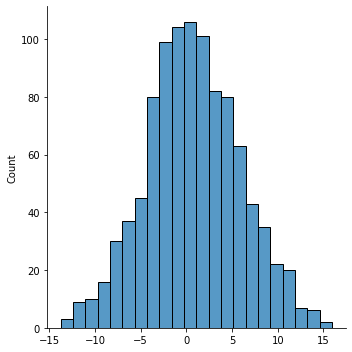

```python
## structured array:
data1 = np.zeros(4, dtype=[('name', 'U20'), ('cyl', 'i4'), ('mpg', 'f8')])
data1['name'] =  ['Honda Civic', 'Toyota Corolla', 'Ferrari Dino', 'Lincoln Continental']
data1['cyl'] =  [4, 4, 6, 8]
data1['mpg'] = [30.4, 33.9, 19.7, 10.4]
print(data1)

## random sub-module of numpy
from numpy import random
# !pip install seaborn
import seaborn as sns # plotting

## generate random normal and show plot
z = random.normal(loc = 1, scale = 5, size = 1000)
sns.displot(z)
```

## `pandas`

```python
import pandas as pd
data = pd.Series([0.25, 0.5, 0.75, 1.0])
print(data.values)
print(data.index)
```

```
[0.25 0.5  0.75 1.  ]
RangeIndex(start=0, stop=4, step=1)
```

```python
## Data Frame
population_dict = {'California': 38332521,
 'Texas': 26448193,
 'New York': 19651127,
 'Florida': 19552860,
 'Illinois': 12882135}
population = pd.Series(population_dict)

population['California':'Florida']

area_dict = {'California': 423967, 'Texas': 695662, 'New York': 141297,
 'Florida': 170312, 'Illinois': 149995}
area = pd.Series(area_dict)

## A dataframe is a dictionary with keys as column names and values as pd.Series
states = pd.DataFrame({'population': population,
 'area': area})

print(states)
```

```
            population    area
California    38332521  423967
Texas         26448193  695662
New York      19651127  141297
Florida       19552860  170312
Illinois      12882135  149995
```

```python
## index
ind = pd.Index([2, 3, 5, 7, 11])
ind

try:
    ind[1] = 0
except:
    "Error found"
```

```python
states['density'] =  states['population']/states['area']

## implicit and explicit index
print(states.iloc[1:, :2])
print(states.loc[:'Florida', ['population', 'density']])
```

```
          population    area
Texas       26448193  695662
New York    19651127  141297
Florida     19552860  170312
Illinois    12882135  149995
            population     density
California    38332521   90.413926
Texas         26448193   38.018740
New York      19651127  139.076746
Florida       19552860  114.806121
```

## Batting Dataset and Salaries Dataset

## Quiz

- Read Baseball datasets from Lahman available in github repository under data using `pd.read_csv()`
- Get columns ('yearID', 'teamID', 'salary') from salary.csv and ('yearID', 'teamID', 'G', 'R', 'HR') from batting.csv. (G: Games, R: Runs, HR: Home Runs)
- find `.head()` method to observe the first 6 rows.
- Use `.describe()` method for obtaining summary for numeric variables.

```python
## salaries
sal = pd.read_csv('data/salaries.csv', header  = 0)[['yearID', 'teamID', 'salary']]
print(sal.head(6))
print('')
print('Describe:')
print(sal.describe().round(2))
```

```
   yearID teamID  salary
0    1985    ATL  870000
1    1985    ATL  550000
2    1985    ATL  545000
3    1985    ATL  633333
4    1985    ATL  625000
5    1985    ATL  800000

Describe:
         yearID       salary
count  26428.00     26428.00
mean    2000.88   2085634.05
std        8.91   3455348.16
min     1985.00         0.00
25%     1994.00    294702.00
50%     2001.00    550000.00
75%     2009.00   2350000.00
max     2016.00  33000000.00
```

```python
batting = pd.read_csv('data/Batting.csv', header = 0)[['yearID', 'teamID', 'G', 'R', 'HR']]
print('Head of batting:')
print(batting.head(6))
```

```
Head of batting:
   yearID teamID   G   R  HR
0    1871    TRO   1   0   0
1    1871    RC1  25  30   0
2    1871    CL1  29  28   0
3    1871    WS3  27  28   2
4    1871    RC1  25  29   0
5    1871    FW1  12   9   0
```

## Quiz. Contd.

```python
merged = pd.merge(sal, batting, how="inner", on=['yearID','teamID'])
```

```python
print(merged.head())
```

```
   yearID teamID  salary   G   R  HR
0    1985    ATL  870000  20   0   0
1    1985    ATL  870000  37   3   0
2    1985    ATL  870000  70  12   0
3    1985    ATL  870000  66   1   1
4    1985    ATL  870000  96  15   3
```

```python
merged.shape
```

```
(1170943, 6)
```

## Quiz Contd.

- Sum rows by year to find `merged1` and by team to find `merged2`
- Create new column `HRG` derived as `HR/G` (Home runs per gamee) for `merged1` and `merged2`.

```python
merged1 = merged.groupby('yearID').sum()
merged2 = merged.groupby('teamID').sum()
print(merged1.head())
```

```
             salary        G       R      HR
yearID
1985    10022511728  1207320  386377   76260
1986    12021585721  1619007  526049  107786
1987    11025831024  1379668  476215  106112
1988    11906535262  1430383  442030   80711
1989    14776180991  1562915  474941   84223
```

```python
merged.loc[:,'HRG'] = merged.loc[:,'HR']/merged.iloc[:, 3]
merged1.loc[:,'HRG'] = merged1.loc[:,'HR']/merged1.iloc[:, 1]
merged2.loc[:,'HRG'] = merged2.loc[:,'HR']/merged2.iloc[:, 1]

merged.loc[:,'RG'] = merged.loc[:,'R']/merged.iloc[:, 3]
merged1.loc[:,'RG'] = merged1.loc[:,'R']/merged1.iloc[:, 1]
merged2.loc[:,'RG'] = merged2.loc[:,'R']/merged2.loc[:, 'G']
```

## Quiz Contd.

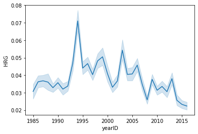

```python
import seaborn as sns
sns.lineplot(data = merged[merged['teamID'] == 'ATL'], x = 'yearID', y = 'HRG')
```

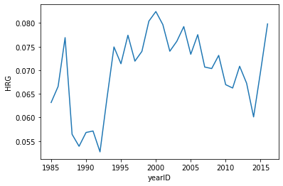

```python
sns.lineplot(data = merged1, x = 'yearID', y = 'HRG')
```

## Miscellaneous important modules

- `scikit`: machine learning algorithms, built on numpy, scipy and matplotlib
- `matplotlib`: more powerful data visualization
- `requests`: web API (application programming interfaces)
- `tensorflow: keras`: dense neural networks
- `imageio`: image processing
- `pybaseball`
- Data visualization: `plotnine` and [seaborn](https://seaborn.pydata.org/tutorial.html)

## `scipy`

- `stats` sub-module in scipy has most statistical functions
- It also contains statistical models like linear regression
- Scipy module also contains minimize function.

## Important References

- [Practical Data Science by Prof.Eubanks](https://www.practicaldatascience.org/html/index.html)
- Anaconda and respective documentations
- [W3Schools](https://www.w3schools.com/python/default.asp)

## Acknowledgements:

- I thank the audience for their patience and enthusiasm.
- I thank Professor Jun Yan whose class has taught a lot
- Also need to acknowledge IMSI bootcamp and the humongous open source available on internet.
- Wish you all the best of luck with working on Python.
- I will be available at surya.eada@uconn.edu

## Questions: